# From genotype data to association evidence

Group homework — instructions and report framework

# Your task

Investigate which variants in the provided dataset show evidence of association with case/control status, and assess how data quality and linkage disequilibrium affect your conclusions.

Complete the full workflow: inspect the data, perform sample and variant QC, test SNP–phenotype associations across all retained variants, correct for multiple testing, and interpret the results.

Build a reproducible analysis in R. You choose the packages, filtering thresholds, primary association method and visualisations. Justify consequential decisions. You are not required to implement standard statistical tests from scratch.

This document contains instructions only. Add your own analysis, code and interpretation under the headings below

# Data and scope

You will receive two tab-separated files:

- `study.tsv`: one individual per row; `sample_id`, `case_control` (0 = control, 1 = case), followed by SNP columns.
- `variants.tsv`: SNP identifiers, chromosome, position and allele labels A1/A2.

Genotypes are 0, 1 or 2 copies of allele A2; missing calls are `NA`. A2 is not necessarily the minor or risk allele. Match annotation to genotype columns by SNP identifier, not by assumed row order. Keep identifiers unchanged during import.

Data are restricted to the chromosome 10.

# 1. Define the analysis before testing associations and inspect the data

Write a short initial plan before inspecting association p-values. Specify your research question, proposed QC criteria, primary genetic model/test, handling of missing calls and sparse genotype counts, and multiple-testing approach.

You may revise the plan after inspecting QC diagnostics. Record the reason for each revision.

**Decision to explain:** What evidence would make you exclude an individual or a variant, and what would merely prompt further investigation?

Verify dimensions, unique identifiers, phenotype coding, genotype values and correspondence with annotation. Describe the numbers of cases and controls and the initial number of variants.

# Our Plan for this Homework

We are given a set of synthetic SNP data from chromosome 10. We are asked to find if any of the SNP variants are associalted to the status, so to find if the presence of a modification in one or both alleles in a precise position, or the absence of a modification of the allele in a precise position, can give information on the status of the individual. We are going to achieve this by doing an accurate statistical analysis on the variants. We are going to prepare the data for our analysis with the industry standard consensus operations that are done to filter out potential flawed data that might hinder the results of our analysis.

In part 1 we preprocess the data by searching if there are wrong elements in our data like a duplicated column/row or values that are not conform to the ones we are prepared to operate on.

In part 2 we apply other Quality control Techniques to the data : we remove any individual whose relative frequency on the variants of the Null (N/A) information is over 2%, because we don’t want to take into account individuals where we don’t have enough information, as the whole sample might be inaccurate or biased.

We filter out SNP with high rates of missing data because they will have a lower power than the other SNPs so we could not handle the information they would give in the same way as the information given by other SNPs with complete data. We also check Minor Allele Frequency : we filter out rare variants as they too lack statistical power, and therefore would not yield tangible results.

We SHOULD also apply Hardy-Weinberg Equilibrium (HWE) on the controls only to look for deviations from expected frequencies, as they often indicate errors.

Part 3 is the heart of the analysis as it contains the statistical tests that give the informations that we then use to decide if any SNP variant in any specific position can give a statistic relevant clue to wether the individual’s status.

Since we are doing multiple testing as there are many positions and variants to test, we decide to correct the results of the Chi square test for the multiple hypothesis testing to limit the type 1 error (false positives) that would otherwise grow to be huge. We decide use the easiest method to do this : the Bonferroni correction.

We are aware that there could be some covariates affecting the analysis, like common ancestry between individuals in the study, so we SHOULD do a Principal Component Analysis to check wether this is the case or not.

# 1. Upload and Preprocess the data

In this section, we preprocess the data to prepare it for quality control. To upload it, we load the study.tsv file and the variants.tsv file into the R environment and check simple feasibility requirements, such as whether the values belong to the set of expected values for each column (0, 1, 2, or NA) and if there are any repeated samples that need to be removed. We check the case/control counts to ensure that both categories are well represented. We then separate the sample IDs and phenotype data from the genomic data to create a standalone genotype matrix. Finally, we print out the dimensions of this matrix and extract the initial information on how much missing data (NAs) is present across the variants.

```r
# Load the study dataset
# check.names = FALSE keeps the SNP identifiers unchanged.
study_data <- read.delim("study.tsv", header = TRUE,
                         stringsAsFactors = FALSE, check.names = FALSE)

# First of all: visualization of the imported data
#View(study_data, title = "Full Study Data")

# Dataset dimensions
cat("Dataset dimensions (rows, columns):", dim(study_data), "\n")
# 494 individuals and 28503 columns (2 info columns + 28501 SNPs)

# Check on possible duplication of the individuals
cat("Total samples:", nrow(study_data), "\n")
cat("Unique sample IDs:", length(unique(study_data$sample_id)), "\n")
# The results confirms that all the rows are unique, so no duplications are present

# Phenotype distribution
# The second column says if the individual is a case or a control, in particular the
# variables associated are 0 = control (the sample doesn't have the disease), 1 = case (has the disease)
cat("\nPhenotype counts:\n")
print(table(study_data$case_control, useNA = "ifany"))
# Automatic check: only values 0 and 1, no NA
stopifnot(all(study_data$case_control %in% c(0, 1)))

# At this moment our data contains both the 'name' of the individuals and their case/control associations. For the analysis we want to do is better to create a new database: the genotypes table contains only individuals positions and SNPs.
genotypes <- study_data[, -(1:2)]
#View(genotypes, title = "After fist 2 column remuval - Genotypes Only")

# The following row will show genotypes dataset dimensions
cat("Genotype matrix dimensions (individuals, SNPs):", dim(genotypes), "\n")

# Check for duplicated SNP identifiers
stopifnot(!any(duplicated(colnames(genotypes))))
cat("Unique SNP identifiers:", length(unique(colnames(genotypes))), "\n")

# Another important step is to check on the kind of data we have in the table.
# In our case 0, 1, 2, NA are the possibilities. By running the following lines of code we are confirming that no wrong elements are present in the table.
unique_genos <- unique(unlist(lapply(genotypes, unique)))
cat("Observed genotype values:", sort(unique_genos, na.last = TRUE), "\n")
stopifnot(all(unique_genos %in% c(0, 1, 2, NA)))

# Once we have note NAs, we should quantified their presence
total_cells <- prod(dim(genotypes))
missing_cells <- sum(is.na(genotypes))
cat("Total missing genotype calls:", missing_cells, "\n")
cat("Percentage of missing data across all genotypes:", round((missing_cells / total_cells) * 100, 2), "%\n")

# Variants with no observed genotype (all NA)
cat("Variants with all genotypes missing:",
    sum(colSums(!is.na(genotypes)) == 0), "\n")
```

```
## Dataset dimensions (rows, columns): 494 28503
## Total samples: 494
## Unique sample IDs: 494
##
## Phenotype counts:
##
##   0   1
## 227 267
## Genotype matrix dimensions (individuals, SNPs): 494 28501
## Unique SNP identifiers: 28501
## Observed genotype values: 0 1 2 NA
## Total missing genotype calls: 140708
## Percentage of missing data across all genotypes: 1 %
## Variants with all genotypes missing: 0
```

# 2 . Quality Control

**Decision to explain:** Which QC pipeline have you chosen? Which QC choices had the largest practical effect? Why is that choice defensible?

Choose and justify your thresholds; distinguish a diagnostic flag from an automatic exclusion. Consider how sample and variant filtering affect one another, and repeat relevant summaries after filtering. Handle variants with no observed genotypes explicitly.

Provide a filtering log showing the order of operations and the numbers of individuals and variants retained after each step. Avoid counting the same exclusion twice. If a check removes nothing, report that result; exclusions are not a goal in themselves.

## Our Quality Control pipeline explained

We implemented a sequential quality control pipeline that relies on the concepts we have seen in class. We first generate histograms of missingness and Minor Allele Frequency (MAF), which help us understand the data distribution before establishing strict numerical thresholds that trigger automatic exclusions.

### Missingness Control

When we consider how sample and variant filtering affect one another, we must account for the fact that if you remove some individuals whose SNPs had a high NA percentage, then the SNPs NA values are reduced and this will lower the number of SNPs positions that we have to remove due to too many NAs. However, because our histograms reveal that individual missingness is uniformly low across the board, we bypass sample exclusions entirely to preserve our dataset. For our variants, we set an automatic exclusion threshold for SNPs with greater than 2% missingness to eliminate error-prone data.

### Allele frequency control

We know that our final goal is to apply statistical tests to understand if some SNP positions are correlated to the phenotype (case/control) It is important to have enough samples in every SNP variant if we want to do a statistical analysis, otherwise the population would be too small compared to the universe of all individuals to actually get statistically relevant results. This is the reason we check the Minor Allele Frequency.

MAF represents the overall frequency of the less common allele within the dataset. Because every person carries two copies of each SNP, our 494 individuals represent 988 total alleles.

If a specific SNP has a MAF of 1%, it means the minor allele only appears about 10 times across the entire pool of 988. If we were to test a SNP this rare, we would not have enough individuals carrying the variant to achieve a statistically significant result. This means that about between 5 and 10 people have variant 1 or 2 of the SNP, and we cannot perform a powerful statistical analysis that checks correlation with these individuals, their SNP variant and their phenotype.

Therefore, if the MAF is too small, we will have too few indivisuals to get a significant statistical result for that SNP and therefore that SNP is not even considered for analysis.

Therefore, if the MAF is too small, testing the SNP provides no actionable statistical power while unnecessarily increasing our multiple-testing penalty. Consequently, SNPs with a MAF below our threshold are discarded and removed from the association analysis.

We chose 5% Minor Allele Frequency (MAF) threshold. To justify this choice, we can calculate the worst-case scenario for our statistical power based on our sample size. We previously filtered out SNPs with more than 2% missing values, meaning the maximum number of missing individuals for any retained SNP is approximately 10 (2% of 494). In the worst-case scenario, this leaves 484 valid individuals, contributing a total of 968 alleles to the test pool.

Applying a 5% MAF threshold to this minimum pool ensures that the minor allele appears at least 48 times (5% of 968). Even if these alleles are entirely concentrated in homozygous individuals (meaning each person carries two copies of the minor variant), this guarantees a minimum of 24 patients representing the minor genotype.

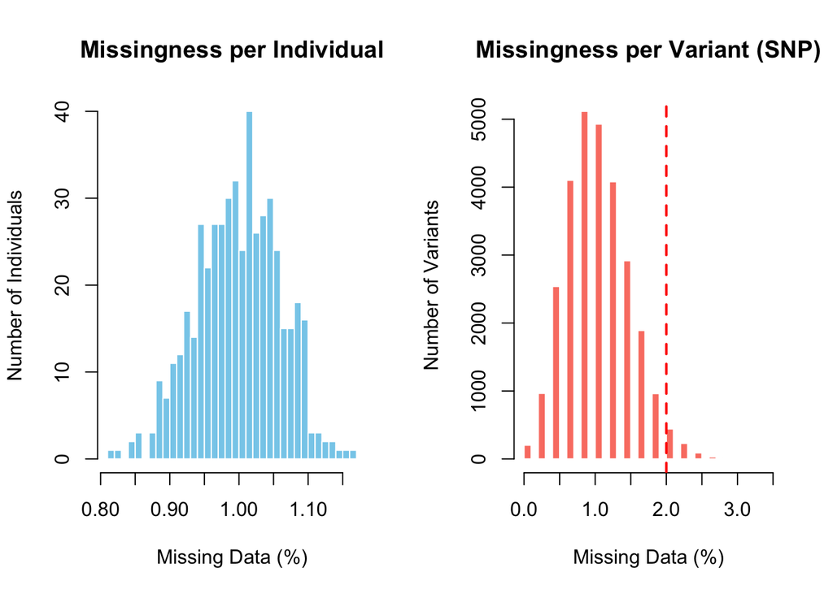

```r
# -----------------------------------------------
#              QUALITY CONTROL
# -----------------------------------------------

# Now we can visualize the distribution of NAs on both rows and column in order to have some more hint on which value could be a good threshold for the following QC.

# Calculated percentage of missingness (NAs) for each individual and SNP
row_na_pct <- rowMeans(is.na(genotypes)) * 100
col_na_pct <- colMeans(is.na(genotypes)) * 100

# Set up the plotting layout to show one figure with two graphs (1 row, 2 columns)
# they only show the data, they remove nothing
par(mfrow = c(1, 2))

# Histogram for Individuals (Row Missingness)
hist(row_na_pct,
     breaks = 30,
     col = "skyblue",
     border = "white",
     main = "Missingness per Individual",
     xlab = "Missing Data (%)",
     ylab = "Number of Individuals")

# Histogram for Variants (Column Missingness)
hist(col_na_pct,
     breaks = 30,
     col = "salmon",
     border = "white",
     main = "Missingness per Variant (SNP)",
     xlab = "Missing Data (%)",
     ylab = "Number of Variants")

# Add a visual threshold line at 2%
abline(v = 2, col = "red", lwd = 2, lty = 2)
```

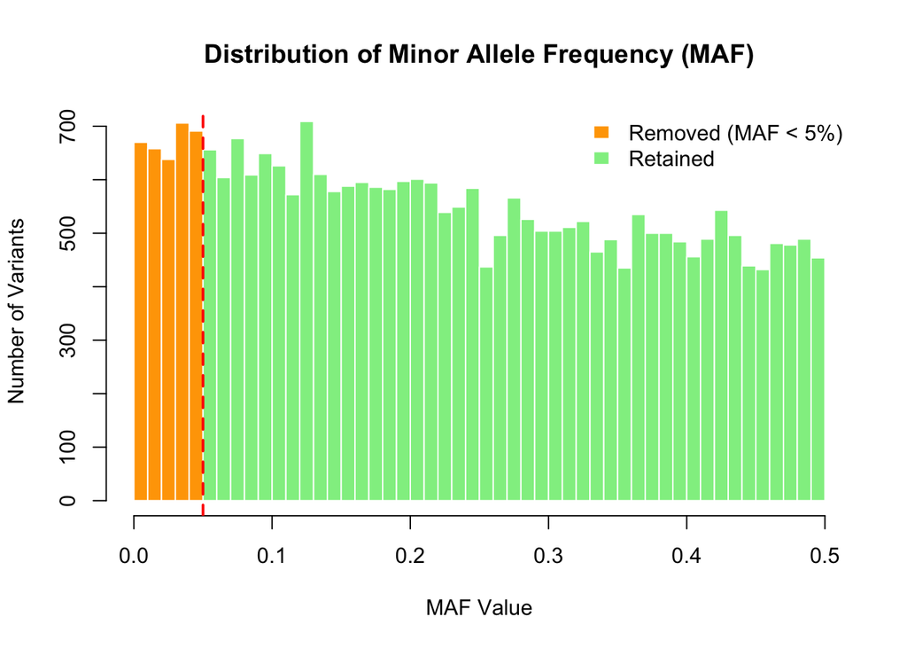

```r
# Reset plotting layout back to default (1x1)
par(mfrow = c(1, 1))

# Print summary statistics to help justify your chosen threshold
cat("\n--- Summary of Individual Missingness (%) ---\n")
print(summary(row_na_pct))

cat("\n--- Summary of Variant Missingness (%) ---\n")
print(summary(col_na_pct))

# The outputs of this part denote that:
# 1) Every single individuals has circa 1% of missing values. The minimum and the maximum percentage of NAs in rows are extremely near (0.81-1.16%), so we choose to not set a threshold. We consider as all the samples have passed the basic quality control.
# 2) On the other hand the variant missingness range is larger (minimum 0% and maximum 3.44%). We should define a threshold. Our decision is to set it at 2% in order to cut off those few variants sitting above 2%.


max_snp_miss <- 0.02  # Maximum allowed missingness per SNP (2%)

# Variant missingness evaluation
snp_missing <- colMeans(is.na(genotypes))
pass_snp_miss <- snp_missing <= max_snp_miss
cat("Variants removed due to missingness (>", max_snp_miss*100, "%):", sum(!pass_snp_miss), "\n")


# 3. MAF Analysis & explicit handling of completely empty variants (all NA)
# A2 is not necessarily the minor allele, so we take the smaller of the two frequencies.
mean_geno <- colMeans(genotypes, na.rm = TRUE)
freq_A2 <- mean_geno / 2
maf <- pmin(freq_A2, 1 - freq_A2)

# MAF threshold chosen (Moved up so the plot can use it for coloring)
min_maf <- 0.05  # minimum minor allele frequency (5%)

# Calculate the histogram data without plotting it yet
maf_hist <- hist(maf[pass_snp_miss], breaks = 50, plot = FALSE)

# Create a color vector: orange for bars below the threshold, lightgreen for the rest
# We check if the left edge of each histogram bin is below our 0.05 threshold
bar_colors <- ifelse(maf_hist$mids < min_maf, "orange", "lightgreen")

# Plot the MAF distribution with the dynamic colors (Diagnostic Flag)
plot(maf_hist,
     col = bar_colors,
     border = "white",
     main = "Distribution of Minor Allele Frequency (MAF)",
     xlab = "MAF Value",
     ylab = "Number of Variants")

# Add the cutoff line and a legend to make it perfectly clear
abline(v = min_maf, col = "red", lwd = 2, lty = 2)
legend("topright", fill = c("orange", "lightgreen"),
       legend = c("Removed (MAF < 5%)", "Retained"), bty = "n", border = "white")
```

```r
# Print MAF summary statistics
cat("MAF Summary Statistics\n")
print(summary(maf))

# Apply combined variant filters and subset the dataset cleanly at the end
# (Handling potential NaN values from variants with 0 observations)
pass_maf <- !is.na(maf) & (maf >= min_maf)
pass_snp <- pass_snp_miss & pass_maf

cat("Final Variant QC Summary (Filtering Log)")
cat("Initial variants:", ncol(genotypes), "\n")
cat("Variants removed by missingness (> 2%):", sum(!pass_snp_miss), "\n")
cat("Variants removed by MAF (< 5%):", sum(pass_snp_miss & !pass_maf), "\n")
cat("Total variants successfully retained:", sum(pass_snp), "\n")

# Create the final clean dataset ready for association testing
study_clean <- study_data[, c(TRUE, TRUE, pass_snp)]
genotypes_clean <- study_clean[, -(1:2)]

# Repeat relevant summaries after filtering
cat("Post-Filtering Summary Verification")
cat("Final dimensions of clean dataset:", dim(genotypes_clean), "\n")
cat("Remaining missing data percentage in clean genotypes:",
    round((sum(is.na(genotypes_clean)) / prod(dim(genotypes_clean))) * 100, 2), "%\n")
# Comment: After filtering out on the columns the percentage of NAs in the database is decreased from 1% to 0.97%
```

```
##
## --- Summary of Individual Missingness (%) ---
##    Min. 1st Qu.  Median    Mean 3rd Qu.    Max.
##  0.8140  0.9579  1.0035  0.9994  1.0421  1.1614
##
## --- Summary of Variant Missingness (%) ---
##    Min. 1st Qu.  Median    Mean 3rd Qu.    Max.
##  0.0000  0.6073  1.0121  0.9994  1.2146  3.4413
## Variants removed due to missingness (> 2 %): 803
## MAF Summary Statistics
##    Min. 1st Qu.  Median    Mean 3rd Qu.    Max.
##  0.0000  0.1057  0.2213  0.2324  0.3567  0.5000
## Final Variant QC Summary (Filtering Log)Initial variants: 28501
## Variants removed by missingness (> 2%): 803
## Variants removed by MAF (< 5%): 3348
## Total variants successfully retained: 24350
## Post-Filtering Summary VerificationFinal dimensions of clean dataset: 494 24350
## Remaining missing data percentage in clean genotypes: 0.97 %
```

### Quality Control Results & Filtering Log

We began with an initial dataset of 494 individuals and 28,501 variants. Our first operation evaluated individual missingness; because a check that removes nothing must be explicitly reported (as exclusions are not a goal in themselves), we note that 0 individuals were excluded, leaving all 494 samples successfully retained. Our second operation applied the 2% variant missingness threshold, which removed 803 error-prone variants. Our third operation applied a 5% MAF threshold to the remaining data, which removed an additional 3,348 ultra-rare variants without overlapping or double-counting the previous missingness exclusions. Following these sequential steps, a total of 24,350 variants were successfully retained.

### Considerations and Practical Effects:

Individual filtering was bypassed as our diagnostic checks confirmed uniform and extremely low missingness (~1%) across all samples, avoiding unnecessary data loss. For the variants, removing those exceeding the 2% missingness threshold eliminated tech-driven errors, while the 5% MAF threshold filtered out ultra-rare alleles that lack statistical power. Together, these steps successfully removed low-quality and uninformative data, reducing the overall dataset dimensions (final dimensions: 494 individuals, 24,350 variants) while improving the global missing data percentage from roughly 1.00% down to 0.97%. This ensures a robust and clean genotype matrix ready for association testing.

# 3. Test SNP–phenotype associations

Apply your prespecified primary method to every variant retained after QC, documenting any variants that cannot be tested. Do not restrict association testing to a few selected SNPs. State the null hypothesis, genotype encoding and assumptions. If you use a chi-squared test, explain its degrees of freedom and assess whether the approximation is appropriate. If you use logistic regression, explain the interpretation of the genotype coefficient and how you handle estimation failures or separation.

**Worked example.** For one tested SNP, show the case/control counts for each observed genotype and explain how these data enter your chosen test or model. State the null hypothesis and interpret its p-value. If you use a regression model, also interpret the estimated effect with its uncertainty. This example complements the analysis of all retained SNPs.

# Explanation of our Statistic tests

We explain step by step what we did in our statistical analysis

### 3A

We opted for omitting missing calls entirely to prevent data distortion rather than misinterpreting them as the reference genotype.

To ensure mathematical validity, we record the exact number of individuals contributing to each test and extract the minimum expected cell count. To handle estimation failures, our function verifies data variability, returning NA for monomorphic variants to prevent crashes. Crucially, while our 5% MAF threshold guarantees at least 24 minor genotypes, phenotype imbalances can still push expected cell counts below 20. We calculate and flag these low expected counts to assess the approximation’s reliability, ensuring no warnings are silently discarded.

### 3B

In this section, we provide a worked example to transparently illustrate our statistical methodology on a single variant. Rather than arbitrarily selecting a variant, we dynamically isolate the SNP with the strongest statistical signal (the lowest raw p-value) from our full analysis. We construct and display the observed 2x3 contingency table to detail the exact case and control counts across all three genotype categories. Next, we compute and print the expected counts under the null hypothesis (no association). This explicitly demonstrates how the raw count data enters the Chi-squared model and allows us to manually verify the assumption that expected cell counts remain adequate for the approximation. Finally, we extract the test statistic, degrees of freedom, and p-value. To ensure rigorous and unbiased evaluation, we implement an automated interpretation block. This dynamically compares the variant’s p-value against both the nominal threshold (p < 0.05) and our conservative Bonferroni threshold, explicitly stating whether we fail to reject the null hypothesis while carefully distinguishing between nominal and genome-wide significance.

### 3C

Because we are evaluating thousands of variants simultaneously across our genomic family of hypotheses, we control the Family-Wise Error Rate (FWER) by applying a Bonferroni correction, yielding an adjusted p-value.

We plot the −log 10(p-values) of all tested variants against their genomic positions, incorporating visual reference lines for both the nominal significance threshold (p=0.05) and the conservative Bonferroni threshold.

Given the massive number of independent tests (m≈24,350) and our restricted sample size, we anticipate that the stringent Bonferroni threshold will likely not be met by any variant.

Therefore, we complement the analysis with a False Discovery Rate (FDR) evaluation using the Benjamini-Hochberg procedure. Because FDR controls the proportion of false discoveries rather than enforcing an absolute zero-tolerance for false positives, it serves as a more statistically powerful tool to check for less strong signals, ensuring that the results are checked thoroughly before making a conclusion.

### 3D and 3E

Finally, we compile a comprehensive results table mapping true physical positions from the variants annotation file, and plot the -log10(p) against the genomic position in Megabases to visually map association evidence across chromosome 10.

In this sections, we outline the multiple-testing parameters, documenting the number of tests, the FWER correction method (Bonferroni), and the calculated decision threshold. Next, we construct a comprehensive results matrix encompassing every analyzed variant. In accordance with the assignment requirements, this table integrates the SNP identifier, mapped physical position (extracted from variants.tsv), effective sample size, allele frequency, test degrees of freedom, raw p-values, adjusted p-values, and a categorical status flag detailing whether the approximation assumptions were fully met or flagged for low expected counts. Finally, because the standard 2-degree-of-freedom Chi-squared test does not yield a directional effect estimate (such as an odds ratio), we dynamically extract and display the raw genotype-by-phenotype count matrices for the five most significant variants.

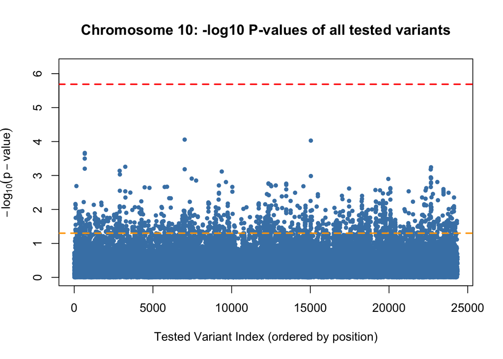

```r
# ------------------------------------------
#          ASSOCIATION TEST
# ------------------------------------------


### 3A. TEST SNP-PHENOTYPE ASSOCIATIONS (Chi-squared Test)

# The first column of the table is re-named as 'phenotype'
phenotype <- study_clean$case_control

# A personalized function is created to test association using the Chi-squared test with 2x3 contingency table

test_snp_chisq <- function(snp_vector) {
  # First of all it removes missing values
  valid_idx <- !is.na(snp_vector) & !is.na(phenotype)
  s <- snp_vector[valid_idx]
  p <- phenotype[valid_idx]
  n <- length(s)

  # Check for variability in genotypes and phenotype: The following lines check the variability of both variants and individuals. A 3x2 Chi-squared test requires sufficient observations across genotype categories (0, 1, 2) and phenotypic classes (cases/controls). If data are monomorphic or lack variation, the contingency table will    have empty cells or dimensions smaller than 2x2, causing the statistical test to fail or crash the program. Thus, untestable variants safely return NA.

  if (length(unique(s)) <= 1 || length(unique(p)) <= 1) {
    return(c(n = n, statistic = NA, df = NA, min_expected = NA, p_value = NA))
  }

  # Contingency table (Genotype: 0, 1, 2 | Phenotype: Controls 0, Cases 1)
  tbl <- table(s, p)

  # Perform Chi-squared test
  chisq_res <- suppressWarnings(chisq.test(tbl, correct = FALSE))

  return(c(n = n, statistic = unname(chisq_res$statistic),
           df = unname(chisq_res$parameter),
           min_expected = min(chisq_res$expected),
           p_value = chisq_res$p.value))
}

# Apply the test to all retained variants
chisq_results <- t(sapply(as.data.frame(genotypes_clean), test_snp_chisq))
chisq_results <- as.data.frame(chisq_results)

cat("\n Chi-squared Association Test \n")
cat("Variants tested:", sum(!is.na(chisq_results$p_value)), "\n")
cat("Variants not testable (p-value NA):", sum(is.na(chisq_results$p_value)), "\n")
cat("Degrees of freedom of the tests:\n")
print(table(chisq_results$df, useNA = "ifany"))
cat("Variants with an expected count < 20 (approximation less reliable):",
    sum(chisq_results$min_expected < 20, na.rm = TRUE), "\n")
# Comparing the number of SNPs in the clean dataset with the successfully tested variants
# confirms that the Chi-squared test was successfully applied to every retained column,
# ensuring no SNPs were skipped or lost during the automated screening process.


### 3B. WORKED EXAMPLE FOR A SINGLE SNP

# We use the SNP with the smallest raw p-value (it is also the starting point of
# the LD analysis), any other column can be singularly evaluated
example_col <- which.min(chisq_results$p_value)
example_snp_name <- colnames(genotypes_clean)[example_col]
example_snp_data <- genotypes_clean[, example_col]

cat("\n Worked Example for SNP", example_snp_name, "\n")

# A. Contingency table
obs_table <- table(phenotype, example_snp_data, useNA = "no")
print("Contingency Table (Rows = Controls 0, Cases 1 | Columns = Genotypes 0, 1, 2):")
print(obs_table)

# B. Run the Chi-squared test on the single SNP
ex_chisq <- chisq.test(obs_table, correct = FALSE)

# Expected counts under H0 (how the data enter the test: observed vs expected
# counts in each cell; an expected count < 5 means the approximation is less reliable)
cat("\nExpected counts under H0 (no association):\n")
print(round(ex_chisq$expected, 1))

# C. Extract and print results
stat_val <- ex_chisq$statistic
df_val <- ex_chisq$parameter
p_val_ex <- ex_chisq$p.value

cat(sprintf("\nChi-squared Statistic: %.4f\n", stat_val))
cat(sprintf("Degrees of Freedom: %d\n", df_val))
cat(sprintf("P-value: %.4e\n", p_val_ex))
cat(sprintf("P-value in the full analysis (3A): %.4e\n", chisq_results$p_value[example_col]))

# D. Authomatization of the output
# The p-value is nominal (one test out of m) and is compared with the Bonferroni
# threshold, so that no claim is made without correcting for multiple testing
m_tests <- sum(!is.na(chisq_results$p_value))
bonf_threshold <- 0.05 / m_tests

if (p_val_ex <= bonf_threshold) {
  cat("Interpretation: The p-value is below the Bonferroni threshold (", format(bonf_threshold, digits = 3), "). We reject the null hypothesis: there is evidence of association between this genotype and disease status (association, not causation).\n")
} else if (p_val_ex < 0.05) {
  cat("Interpretation: The p-value is below 0.05 but above the Bonferroni threshold (", format(bonf_threshold, digits = 3), "). The association is only nominal: after correcting for ", m_tests, " tests we cannot distinguish it from chance, so we do not reject the null hypothesis.\n")
} else {
  cat("Interpretation: The p-value is above 0.05. We fail to reject the null hypothesis; there is insufficient statistical evidence of association for this variant.\n")
}


### 3C. VISUALIZATION AND SUMMARY OF ASSOCIATION RESULTS

# Remove NA p-values prior to plotting
valid_p_vals <- chisq_results$p_value[!is.na(chisq_results$p_value)]
log10_p <- -log10(valid_p_vals)

#Bonferroni threshold
num_tests <- sum(!is.na(chisq_results$p_value))
decision_threshold <- 0.05 / num_tests

# Quality Score Plot: -log10(p-values) is evaluated across all tested variants.
# The plot has index that represents each individual SNP tested ordered by position on the x-axis, while on the y-axis is represented the strenght of the statistical association.
# An orange line was plot at -log10(alpha = 0.05) to underline the cutoff between the significant and the not significant variants considering the significance threshold at 0.05.
# The red dashed line represents the Bonferroni threshold (alpha / number of SNPs)

plot(log10_p,
     pch = 20,
     col = "steelblue",
     main = "Chromosome 10: -log10 P-values of all tested variants",
     xlab = "Tested Variant Index (ordered by position)",
     ylab = expression(-log[10](p-value)),
     ylim = c(0, max(log10_p, -log10(decision_threshold)) + 0.5))

# Significant threshold lines added to the plot:

# 1. Nominal threshold at p = 0.05
abline(h = -log10(0.05), col = "orange", lty = 2, lwd = 2)

# 2. Bonferroni threshold
abline(h = -log10(decision_threshold), col = "red", lty = 2, lwd = 2)
```

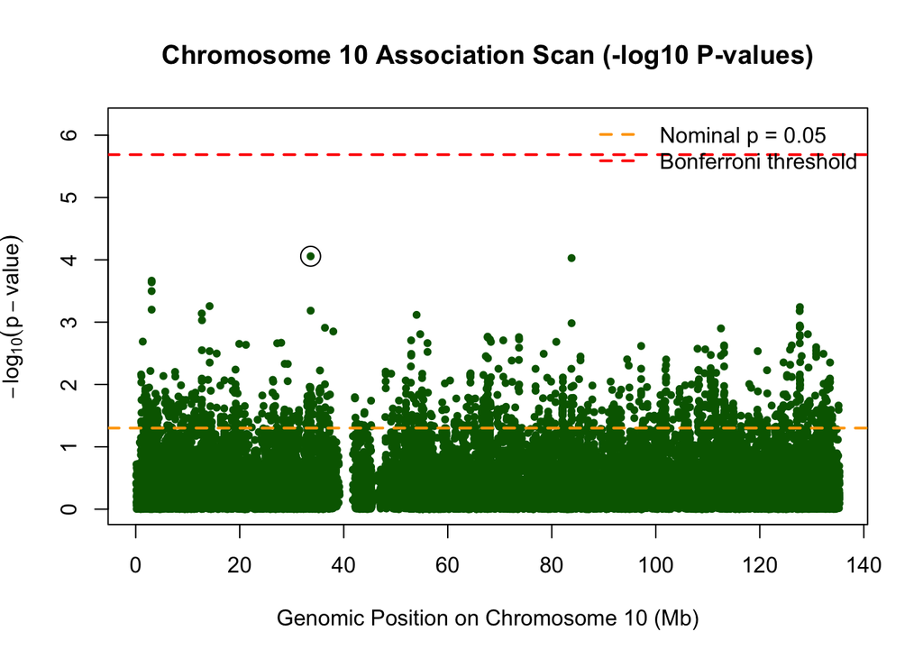

```
##
##  Chi-squared Association Test
## Variants tested: 24350
## Variants not testable (p-value NA): 0
## Degrees of freedom of the tests:
##
##     1     2
##   279 24071
## Variants with an expected count < 20 (approximation less reliable): 14292
##
##  Worked Example for SNP rs2776932
## [1] "Contingency Table (Rows = Controls 0, Cases 1 | Columns = Genotypes 0, 1, 2):"
##          example_snp_data
## phenotype   0   1   2
##         0   9  89 129
##         1   7  59 200
##
## Expected counts under H0 (no association):
##          example_snp_data
## phenotype   0    1     2
##         0 7.4 68.1 151.5
##         1 8.6 79.9 177.5
##
## Chi-squared Statistic: 18.6850
## Degrees of Freedom: 2
## P-value: 8.7620e-05
## P-value in the full analysis (3A): 8.7620e-05
## Interpretation: The p-value is below 0.05 but above the Bonferroni threshold ( 2.05e-06 ). The association is only nominal: after correcting for  24350  tests we cannot distinguish it from chance, so we do not reject the null hypothesis.
## No SNPs exceeded the FDR threshold (q <= 0.05).
##
## === Multiple Testing Summary ===
## Method: Bonferroni correction (controls FWER)
## Number of tests (m): 24350
## Decision threshold (alpha / m): 2.05e-06
## Variants passing Bonferroni correction: 0
##
## === Top 10 Associated Variants ===
##        SNP_ID  Position   N  Freq DF    Raw_P Adj_P           Status
## 1   rs2776932  33632412 493 0.817  2 8.76e-05     1          Success
## 2  rs12217544  83807223 491 0.566  2 9.37e-05     1          Success
```

[output cut: 25 more lines]

```
## Phenotype   0   1   2
##         0 172  51   3
##         1 239  25   2
##
## Variant: rs2892551
##          Genotype
## Phenotype   0   1   2
##         0   3  51 171
##         1   2  25 237
##
## Variant: rs2388583
##          Genotype
## Phenotype   0   1   2
##         0 163  57   5
##         1 231  33   2
```

```r
# 3. FDR (Benjamini-Hochberg) threshold evaluation
# Extract valid raw p-values
raw_p <- chisq_results$p_value[!is.na(chisq_results$p_value)]

# Compute adjusted p-values using the Benjamini-Hochberg (FDR) method
fdr_p <- p.adjust(raw_p, method = "BH")

# Find the maximum raw p-value among markers passing FDR <= 0.05
significant_fdr_p <- raw_p[fdr_p <= 0.05]

if (length(significant_fdr_p) > 0) {
  fdr_threshold <- max(significant_fdr_p)
  cat(sprintf("Raw p-value threshold for FDR (q <= 0.05): %.4e (-log10 = %.2f)\n",
              fdr_threshold, -log10(fdr_threshold)))
  abline(h = -log10(fdr_threshold), col = "blue", lty = 2, lwd = 2)

} else {
  fdr_threshold <- NA
  cat("No SNPs exceeded the FDR threshold (q <= 0.05).\n")
}


# ==========================================
# 3D. MULTIPLE TESTING CORRECTION & RESULTS TABLE
# ==========================================

# Get the genomic positions (matched by SNP identifier)
variants <- read.delim("variants.tsv", header = TRUE,
                       stringsAsFactors = FALSE, check.names = FALSE)

# Multiple Testing Summary Calculations
num_tests <- sum(!is.na(chisq_results$p_value))
raw_p <- chisq_results$p_value
adjusted_p <- p.adjust(raw_p, method = "bonferroni")
decision_threshold <- 0.05 / num_tests
passing_variants <- sum(adjusted_p <= 0.05, na.rm = TRUE)

# Print clean, concise summary
cat("\n=== Multiple Testing Summary ===\n")
cat("Method: Bonferroni correction (controls FWER)\n")
cat("Number of tests (m):", num_tests, "\n")
cat(sprintf("Decision threshold (alpha / m): %.2e\n", decision_threshold))
cat("Variants passing Bonferroni correction:", passing_variants, "\n\n")

# Build the comprehensive results table
snp_ids <- colnames(genotypes_clean)
# Real positions on chromosome 10, matched by SNP identifier
snp_positions <- variants$position[match(snp_ids, variants$snp_id)]
stopifnot(!anyNA(snp_positions))

# Compute sample size and allele frequency for each variant
sample_sizes <- apply(genotypes_clean, 2, function(x) sum(!is.na(x) & !is.na(phenotype)))
allele_freqs <- colMeans(genotypes_clean, na.rm = TRUE) / 2

# Shortened status column for cleaner printing
analysis_status <- ifelse(is.na(raw_p), "Failed",
                   ifelse(chisq_results$min_expected < 5, "Warning: Exp < 5", "Success"))

# Create data frame with concise column names for readable console/HTML output
results_table <- data.frame(
  SNP_ID = snp_ids,
  Position = snp_positions,
  N = sample_sizes,
  Freq = round(allele_freqs, 3),
  DF = chisq_results$df,
  Raw_P = signif(raw_p, 3),
  Adj_P = signif(adjusted_p, 3),
  Status = analysis_status,
  stringsAsFactors = FALSE
)

# Preview of the 10 variants with the smallest raw p-value
cat("=== Top 10 Associated Variants ===\n")
# We drop the row names for a cleaner print layout
top_10 <- head(results_table[order(results_table$Raw_P), ], 10)
rownames(top_10) <- NULL
print(top_10)

# Genotype counts by phenotype for the 5 variants with the smallest p-values
# (Provided because Chi-squared does not produce an effect estimate)
cat("\n=== Genotype Counts by Phenotype (Top 5 Variants) ===\n")
for (k in order(raw_p)[1:5]) {
  cat("\nVariant:", snp_ids[k], "\n")
  print(table(Phenotype = phenotype, Genotype = genotypes_clean[, k]))
}


# ==========================================
# 3E. CHROMOSOME 10 GENOMIC POSITION PLOT
# ==========================================

# y-axis limit computed so that the Bonferroni line is always visible
y_max <- max(-log10(decision_threshold),
             -log10(results_table$Raw_P), na.rm = TRUE) + 0.5

# Plot -log10(p) against genomic position along chromosome 10
# Position shown in megabases (Mb) instead of base pairs
plot(results_table$Position / 1e6, -log10(results_table$Raw_P),
     pch = 20,
     col = "darkgreen",
     main = "Chromosome 10 Association Scan (-log10 P-values)",
     xlab = "Genomic Position on Chromosome 10 (Mb)",
     ylab = expression(-log[10](p-value)),
     ylim = c(0, y_max))

# Add significance threshold lines
abline(h = -log10(0.05), col = "orange", lty = 2, lwd = 2)        # Nominal threshold
abline(h = -log10(decision_threshold), col = "red", lty = 2, lwd = 2) # Bonferroni threshold

# Highlight the variant with the smallest p-value (used later for the LD region)
top_idx <- which.min(results_table$Raw_P)
points(results_table$Position[top_idx] / 1e6, -log10(results_table$Raw_P[top_idx]),
       pch = 1, cex = 2, col = "black")

# Legend
legend("topright", bty = "n", lty = 2, lwd = 2, col = c("orange", "red"),
       legend = c("Nominal p = 0.05", "Bonferroni threshold"))
```